# Apriori algorithm: small example

We will use the `arules` package to generate association rules and the `arulesViz` package to visualize them.

```r
library(arules)
library(arulesViz)
library(tidyverse)
```

Documentation on the `arules` and `arulesViz` packages can be found here:

https://cran.r-project.org/web/packages/arules/vignettes/arules.pdf

https://cran.r-project.org/web/packages/arulesViz/vignettes/arulesViz.pdf

## Example 1

In this example we will define the **transaction** from a *list* object:

```r
# define lists
shopping_list <- list(
  c("flowers", "card", "soda"),
  c("toy", "flowers", "balloon", "candy"),
  c("card", "candy", "flowers"),
  c("toy", "balloons", "soda"),
  c("flowers", "card", "soda")
)
```

We now change the class of the list into a *transactions* class object (the `transactions` class represents transaction data used for mining itemsets or rules):

```r
# coerce as transaction
shopping_tr <- as(shopping_list, "transactions")
```

The apriori algorithm is used below to generate rules from our shopping list:

```r
# uses the apriori() function
shopping_rules <- apriori(shopping_tr,
                          parameter = list(support = .1,
                                           confidence = .25,
                                           minlen = 2))
```

```
Apriori

Parameter specification:
```

|  | confidence | minval | smax | arem | aval | originalSupport | maxtime | support | minlen | maxlen | target | ext |
| --- | --- | --- | --- | --- | --- | --- | --- | --- | --- | --- | --- | --- |
|  | 0.25 | 0.1 | 1 | none | FALSE | TRUE | 5 | 0.1 | 2 | 10 | rules | TRUE |

```
Algorithmic control:
```

|  | filter | tree | heap | memopt | load | sort | verbose |
| --- | --- | --- | --- | --- | --- | --- | --- |
|  | 0.1 | TRUE | TRUE | FALSE | TRUE | 2 | TRUE |

```
Absolute minimum support count: 0

set item appearances ...[0 item(s)] done [0.00s].
set transactions ...[7 item(s), 5 transaction(s)] done [0.00s].
sorting and recoding items ... [7 item(s)] done [0.00s].
creating transaction tree ... done [0.00s].
checking subsets of size 1 2 3 4 done [0.00s].
writing ... [51 rule(s)] done [0.00s].
creating S4 object  ... done [0.00s].
```

We use the `inspect()` function to check the top 3 rules based on *confidence*

```r
# inspect by confidence
inspect(head(sort(shopping_rules, by = "confidence"), 3))
```

|  | lhs |  | rhs | support | confidence | coverage | lift | count |
| --- | --- | --- | --- | --- | --- | --- | --- | --- |
| [1] | {balloons} | => | {toy} | 0.2 | 1 | 0.2 | 2.500000 | 1 |
| [2] | {balloons} | => | {soda} | 0.2 | 1 | 0.2 | 1.666667 | 1 |
| [3] | {balloon} | => | {candy} | 0.2 | 1 | 0.2 | 2.500000 | 1 |

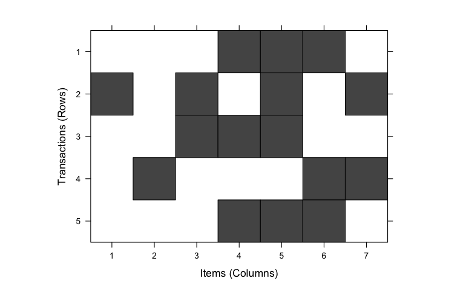

```r
image(shopping_tr)
```

## Example 2

In this example we create transactions from a data frame:

```r
## creating transactions from data.frame
students_df <- data.frame(
  age = factor(c(6, 8, NA, 9, 16)),
  grade = factor(c("A", "C", "F", NA, "C")),
  pass = c(T, T, F, T, T)
)
```

Again, we *coerce* the data frame as a `transactions` object:

```r
## coerce
students_tr <- as(students_df, "transactions")
```

We can inspect this new object:

```r
# inspect
inspect(students_tr)
```

|  | items | transactionID |
| --- | --- | --- |
| [1] | {age=6,grade=A,pass} | 1 |
| [2] | {age=8,grade=C,pass} | 2 |
| [3] | {grade=F} | 3 |
| [4] | {age=9,pass} | 4 |
| [5] | {age=16,grade=C,pass} | 5 |

Below the apriori algorithm is used with its default values:

```r
students_rules <- apriori(students_tr)
```

```
Apriori

Parameter specification:
```

|  | confidence | minval | smax | arem | aval | originalSupport | maxtime | support | minlen | maxlen | target | ext |
| --- | --- | --- | --- | --- | --- | --- | --- | --- | --- | --- | --- | --- |
|  | 0.8 | 0.1 | 1 | none | FALSE | TRUE | 5 | 0.1 | 1 | 10 | rules | TRUE |

```
Algorithmic control:
```

|  | filter | tree | heap | memopt | load | sort | verbose |
| --- | --- | --- | --- | --- | --- | --- | --- |
|  | 0.1 | TRUE | TRUE | FALSE | TRUE | 2 | TRUE |

```
Absolute minimum support count: 0

set item appearances ...[0 item(s)] done [0.00s].
set transactions ...[8 item(s), 5 transaction(s)] done [0.00s].
sorting and recoding items ... [8 item(s)] done [0.00s].
creating transaction tree ... done [0.00s].
checking subsets of size 1 2 3 done [0.00s].
writing ... [18 rule(s)] done [0.00s].
creating S4 object  ... done [0.00s].
```

Let us inspect the generated rules this time based on the top 6 rules by *lift*:

```r
students_rules %>%
  sort( . , by = "lift") %>%
  head() %>%
  inspect()
```

|  | lhs |  | rhs | support | confidence | coverage | lift | count |
| --- | --- | --- | --- | --- | --- | --- | --- | --- |
| [1] | {grade=A} | => | {age=6} | 0.2 | 1 | 0.2 | 5.0 | 1 |
| [2] | {age=6} | => | {grade=A} | 0.2 | 1 | 0.2 | 5.0 | 1 |
| [3] | {grade=A,pass} | => | {age=6} | 0.2 | 1 | 0.2 | 5.0 | 1 |
| [4] | {age=6,pass} | => | {grade=A} | 0.2 | 1 | 0.2 | 5.0 | 1 |
| [5] | {age=8} | => | {grade=C} | 0.2 | 1 | 0.2 | 2.5 | 1 |
| [6] | {age=16} | => | {grade=C} | 0.2 | 1 | 0.2 | 2.5 | 1 |

## Example 3

First, let us create transactions from a list:

```r
publix <- list(
  c("milk", "tea", "cake"),
  c("eggs", "tea", "cold drink"),
  c("milk", "eggs", "tea", "cold drink"),
  c("eggs", "cold drink"),
  c("juice")
)
```

Convert list to transactions class:

```r
publix_tr <- as(publix, "transactions")
```

An item frequency plot can be created using the `itemFrequencyPlot()` function:

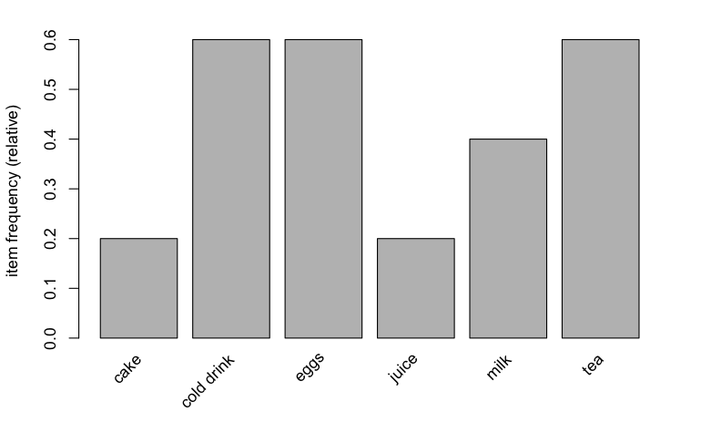

```r
itemFrequencyPlot(publix_tr)
```

Use apriori algorithm with support set to 0.4:

```r
publix_rules <- apriori(publix_tr, parameter = list(support = .4))
```

```
Apriori

Parameter specification:
```

|  | confidence | minval | smax | arem | aval | originalSupport | maxtime | support | minlen | maxlen | target | ext |
| --- | --- | --- | --- | --- | --- | --- | --- | --- | --- | --- | --- | --- |
|  | 0.8 | 0.1 | 1 | none | FALSE | TRUE | 5 | 0.4 | 1 | 10 | rules | TRUE |

```
Algorithmic control:
```

|  | filter | tree | heap | memopt | load | sort | verbose |
| --- | --- | --- | --- | --- | --- | --- | --- |
|  | 0.1 | TRUE | TRUE | FALSE | TRUE | 2 | TRUE |

```
Absolute minimum support count: 2

set item appearances ...[0 item(s)] done [0.00s].
set transactions ...[6 item(s), 5 transaction(s)] done [0.00s].
sorting and recoding items ... [4 item(s)] done [0.00s].
creating transaction tree ... done [0.00s].
checking subsets of size 1 2 3 done [0.00s].
writing ... [5 rule(s)] done [0.00s].
creating S4 object  ... done [0.00s].
```

Inspect the rules:

```r
inspect(publix_rules)
```

|  | lhs |  | rhs | support | confidence | coverage | lift | count |
| --- | --- | --- | --- | --- | --- | --- | --- | --- |
| [1] | {milk} | => | {tea} | 0.4 | 1 | 0.4 | 1.666667 | 2 |
| [2] | {cold drink} | => | {eggs} | 0.6 | 1 | 0.6 | 1.666667 | 3 |
| [3] | {eggs} | => | {cold drink} | 0.6 | 1 | 0.6 | 1.666667 | 3 |
| [4] | {cold drink,tea} | => | {eggs} | 0.4 | 1 | 0.4 | 1.666667 | 2 |
| [5] | {eggs,tea} | => | {cold drink} | 0.4 | 1 | 0.4 | 1.666667 | 2 |

Let us visualize these rules using tools from the `arulesViz` package.

```r
plot(publix_rules, method = "graph", control = list(type = "items"), engine = "htmlwidget")
```

[output not shown]

[interactive chart not shown]